# **Unsupervised Learning Project Solution**

## **3. Model building**

```python
model_comparision_list = []

from sklearn.metrics import accuracy_score,confusion_matrix,precision_score,recall_score,f1_score,classification_report

# Evaluating classifier performance
def evaluate_model_perf(model_descr, y, y_pred):
  print('-'*40)
  print("Classification report:")
  print(classification_report(y,y_pred))
  print('-'*40)
  print('\nAccuracy Score:\t{:.2f} '.format(accuracy_score(y,y_pred)))
  print('\nPrecision:\t{:.2f} '.format(precision_score(y,y_pred, average='macro')))
  print('\nRecall:\t\t{:.2f} '.format(recall_score(y,y_pred, average='macro')))
  print('\nF1 Score:\t{:.2f} '.format(f1_score(y,y_pred, average='macro')))
  print('-'*40)
  print("Confusion Matrix:")
  print(confusion_matrix(y,y_pred))
  print('-'*40)
  # Calculate & Create the confusion matrix
  cm = confusion_matrix(y, y_pred, labels=['car','bus','van'])
  df_cm = pd.DataFrame(cm, index = [i for i in ['car','bus','van']],
                  columns = [i for i in ['car','bus','van']])
  # Plot the confusion matrix
  sns.heatmap(df_cm, annot=True, fmt = 'g');

  # performance_matrix list of this model
  performance_matrix = []
  performance_matrix.append(model_descr)
  performance_matrix.append(accuracy_score(y,y_pred)*100)
  performance_matrix.append(precision_score(y,y_pred, average='macro')*100)
  performance_matrix.append(recall_score(y,y_pred, average='macro')*100)
  performance_matrix.append(f1_score(y,y_pred, average='macro')*100)
  # Store the performance per model

  model_comparision_list.append(performance_matrix)

def display_model_matrix():
  final_perf_df = pd.DataFrame(model_comparision_list, columns=['Model','Accuracy','Precision','Recall','F1 Score'])
  final_perf_df.sort_values(by=['Accuracy'], inplace=True, ascending=False)

  print('-'*80)
  print("Model Performance Comparision Matrix")
  print('-'*80)
  print(final_perf_df)
  print('-'*80)
```

**A. Train a base Classification model using SVM.**

```python
from sklearn.svm import SVC

svm_base = SVC()
svm_base.fit(Xscale, yscale)
y_pred = svm_base.predict(Xscale)
```

**B. Print Classification metrics for train data.**

```
----------------------------------------
Classification report:
              precision    recall  f1-score   support

         bus       0.99      0.98      0.98       218
         car       0.99      0.98      0.99       429
         van       0.95      0.98      0.97       199

    accuracy                           0.98       846
   macro avg       0.98      0.98      0.98       846
weighted avg       0.98      0.98      0.98       846

----------------------------------------

Accuracy Score:	0.98

Precision:	0.98

Recall:		0.98

F1 Score:	0.98
----------------------------------------
Confusion Matrix:
[[214   0   4]
 [  2 421   6]
 [  1   3 195]]
----------------------------------------
```

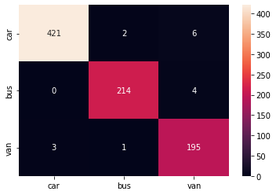

```python
evaluate_model_perf('SVC Base Model without PCA', yscale, y_pred)
```

**C. Apply PCA on the data with 10 components.**

```python
from sklearn.decomposition import PCA
pca_10 = PCA(n_components=10)
pca_10.fit(Xscale)
```

```
PCA(n_components=10)
```

```python
np.cumsum(pca_10.explained_variance_ratio_)
```

```
array([0.52186034, 0.68915802, 0.79478441, 0.86025901, 0.9111577 ,
       0.94112183, 0.96103549, 0.97335049, 0.98226265, 0.98735979])
```

```python
# generating the covariance matrix and the eigen values for the PCA analysis
cov_matrix = np.cov(Xscale.T) # the relevanat covariance matrix
print('Covariance Matrix \n%s', cov_matrix)

#generating the eigen values and the eigen vectors
e_vals, e_vecs = np.linalg.eig(cov_matrix)
print('Eigenvectors \n%s' %e_vecs)
print('\nEigenvalues \n%s' %e_vals)
```

```
Covariance Matrix
%s [[ 1.00118343  0.68569786  0.79086299  0.69055952  0.09164265  0.14842463
   0.81358214 -0.78968322  0.81465658  0.67694334  0.76297234  0.81497566
   0.58593517 -0.24988794  0.23635777  0.15720044  0.29889034  0.36598446]
 [ 0.68569786  1.00118343  0.79325751  0.6216467   0.15396023  0.25176438
   0.8489411  -0.82244387  0.84439802  0.96245572  0.79724837  0.83693508
   0.92691166  0.05200785  0.14436828 -0.01145212 -0.10455005  0.04640562]
 [ 0.79086299  0.79325751  1.00118343  0.76794246  0.15864319  0.26499957
   0.90614687 -0.9123854   0.89408198  0.77544391  0.86253904  0.88706577
   0.70660663 -0.22621115  0.1140589   0.26586088  0.14627113  0.33312625]
 [ 0.69055952  0.6216467   0.76794246  1.00118343  0.66423242  0.45058426
   0.73529816 -0.79041561  0.70922371  0.56962256  0.79435372  0.71928618
   0.53700678 -0.18061084  0.04877032  0.17394649  0.38266622  0.47186659]
 [ 0.09164265  0.15396023  0.15864319  0.66423242  1.00118343  0.64949139
   0.10385472 -0.18325156  0.07969786  0.1270594   0.27323306  0.08929427
   0.12211524  0.15313091 -0.05843967 -0.0320139   0.24016968  0.26804208]
 [ 0.14842463  0.25176438  0.26499957  0.45058426  0.64949139  1.00118343
   0.16638787 -0.18035326  0.16169312  0.30630475  0.31933428  0.1434227
   0.18996732  0.29608463  0.01561769  0.04347324 -0.02611148  0.14408905]
 [ 0.81358214  0.8489411   0.90614687  0.73529816  0.10385472  0.16638787
   1.00118343 -0.97275069  0.99092181  0.81004084  0.94978498  0.9941867
   0.80082111 -0.02757446  0.07454578  0.21267959  0.00563439  0.1189581 ]
 [-0.78968322 -0.82244387 -0.9123854  -0.79041561 -0.18325156 -0.18035326
  -0.97275069  1.00118343 -0.95011894 -0.77677186 -0.93748998 -0.95494487
  -0.76722075  0.10342428 -0.05266193 -0.18527244 -0.11526213 -0.2171615 ]
 [ 0.81465658  0.84439802  0.89408198  0.70922371  0.07969786  0.16169312
   0.99092181 -0.95011894  1.00118343  0.81189327  0.93533261  0.98938264
   0.79763248 -0.01551372  0.08386628  0.21495454 -0.01867064  0.09940372]
 [ 0.67694334  0.96245572  0.77544391  0.56962256  0.1270594   0.30630475
   0.81004084 -0.77677186  0.81189327  1.00118343  0.74586628  0.79555492
   0.86747579  0.04167099  0.13601231  0.00136727 -0.10407076  0.07686047]
 [ 0.76297234  0.79724837  0.86253904  0.79435372  0.27323306  0.31933428
   0.94978498 -0.93748998  0.93533261  0.74586628  1.00118343  0.94679667
   0.77983844  0.11321163  0.03677248  0.19446837  0.01423606  0.08579656]
 [ 0.81497566  0.83693508  0.88706577  0.71928618  0.08929427  0.1434227
   0.9941867  -0.95494487  0.98938264  0.79555492  0.94679667  1.00118343
   0.79595778 -0.01541878  0.07696823  0.20104818  0.00622636  0.10305714]
 [ 0.58593517  0.92691166  0.70660663  0.53700678  0.12211524  0.18996732
   0.80082111 -0.76722075  0.79763248  0.86747579  0.77983844  0.79595778
   1.00118343  0.19169941  0.16667971 -0.05621953 -0.22471583 -0.11814142]
```

[output cut: 98 more lines]

```
  -5.17222779e-01 -1.93956186e-02 -1.20597635e-01 -3.53723696e-01
   1.86595152e-01  4.34282436e-02  7.67874680e-03  2.31451048e-01
   1.90629960e-01 -1.82212045e-01]
 [ 7.41453913e-02  5.40354258e-01 -3.95242743e-02 -4.74890311e-02
   2.98614819e-02 -2.41222817e-01  1.57237839e-02  3.04186304e-02
  -1.71506343e-01 -6.41314778e-02 -9.19597847e-02  6.85618161e-01
  -1.42380007e-01 -6.47700819e-03  6.37681817e-03 -2.88502234e-01
  -1.20966490e-01  9.04014702e-02]]

Eigenvalues
[9.40460261e+00 3.01492206e+00 1.90352502e+00 1.17993747e+00
 9.17260633e-01 5.39992629e-01 3.58870118e-01 2.21932456e-01
 1.60608597e-01 9.18572234e-02 6.64994118e-02 4.66005994e-02
 3.57947189e-02 2.96445743e-03 1.00257898e-02 2.74120657e-02
 1.79166314e-02 2.05792871e-02]
```

```python
# the "cumulative variance explained" analysis
tot = sum(e_vals)
var_exp = [( i /tot ) * 100 for i in sorted(e_vals, reverse=True)]
cum_var_exp = np.cumsum(var_exp)
print("Cumulative Variance Explained", cum_var_exp)
```

```
Cumulative Variance Explained [ 52.18603365  68.9158021   79.47844095  86.02590063  91.11576952
  94.11218252  96.10354875  97.33504945  98.22626473  98.73597943
  99.10498391  99.36357011  99.5621946   99.71430385  99.82849808
  99.92791726  99.98355026 100.        ]
```

**D. Visualize Cumulative Variance Explained with Number of Components.**

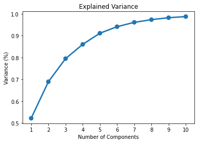

```python
# Plotting the Cumulative Summation of the Explained Variance
plot = sns.pointplot(x = list(range(1,11)), y = np.cumsum(pca_10.explained_variance_ratio_))
plot.set_xlabel('Number of Components')
plot.set_ylabel('Variance (%)')
plot.set_title('Explained Variance');
```

**Observation:** As seen in the plot above, 5 or more components give 90% and above variance explained ratio.

**E. Draw a horizontal line on the above plot to highlight the threshold of 90%.**

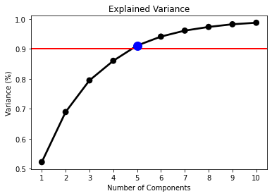

```python
# Plotting the Cumulative Summation of the Explained Variance
plot = sns.pointplot(x = list(range(1,11)), y = np.cumsum(pca_10.explained_variance_ratio_), color='black')
plot.set_xlabel('Number of Components')
plot.set_ylabel('Variance (%)')
plot.set_title('Explained Variance');
plot.axhline(y=0.9, xmin=0, xmax=9, linewidth=2, color='r')
plot.plot([4], [np.cumsum(pca_10.explained_variance_ratio_)[4]], "o", markersize = 12, color = 'blue');
```

**Observation:**

From the above plot, it is seen that 5 components give more than 90% variance explained. Let us select 5 components to proceed further.

**F. Apply PCA on the data. This time Select Minimum Components with 90% or above variance explained.**

```python
pca_5 = PCA(n_components=5)
X_pca_5 = pca_5.fit_transform(Xscale)
X_pca_5.transpose()
```

```
array([[ 3.34162030e-01, -1.59171085e+00,  3.76932418e+00, ...,
         4.80917387e+00, -3.29409242e+00, -4.76505347e+00],
       [-2.19026359e-01, -4.20602982e-01,  1.95282752e-01, ...,
        -1.24931050e-03, -1.00827615e+00,  3.34899728e-01],
       [ 1.00158417e+00, -3.69033854e-01,  8.78587401e-02, ...,
         5.32333105e-01, -3.57003198e-01, -5.68136079e-01],
       [ 1.76612370e-01,  2.33234117e-01,  1.20221219e+00, ...,
         2.95652323e-01, -1.93367514e+00, -1.22480708e+00],
       [ 7.93006862e-02,  6.93948577e-01,  7.31732270e-01, ...,
        -1.34423636e+00,  4.27680209e-02, -5.40510233e-02]])
```

```python
pca_5.components_
```

```
array([[ 2.75283688e-01,  2.93258469e-01,  3.04609128e-01,
         2.67606877e-01,  8.05039890e-02,  9.72756855e-02,
         3.17092750e-01, -3.14133155e-01,  3.13959064e-01,
         2.82830900e-01,  3.09280359e-01,  3.13788457e-01,
         2.72047492e-01, -2.08137692e-02,  4.14555082e-02,
         5.82250207e-02,  3.02795063e-02,  7.41453913e-02],
       [-1.26953763e-01,  1.25576727e-01, -7.29516436e-02,
        -1.89634378e-01, -1.22174860e-01,  1.07482875e-02,
         4.81181371e-02,  1.27498515e-02,  5.99352482e-02,
         1.16220532e-01,  6.22806229e-02,  5.37843596e-02,
         2.09233172e-01,  4.88525148e-01, -5.50899716e-02,
        -1.24085090e-01, -5.40914775e-01, -5.40354258e-01],
       [-1.19922479e-01, -2.48205467e-02, -5.60143254e-02,
         2.75074210e-01,  6.42012966e-01,  5.91801304e-01,
        -9.76283108e-02,  5.76484384e-02, -1.09512416e-01,
        -1.70641987e-02,  5.63239801e-02, -1.08840729e-01,
        -3.14636493e-02,  2.86277015e-01, -1.15679354e-01,
        -7.52828901e-02,  8.73592034e-03,  3.95242743e-02],
       [ 7.83843562e-02,  1.87337408e-01, -7.12008426e-02,
        -4.26053415e-02,  3.27257119e-02,  3.14147277e-02,
        -9.57485748e-02,  8.22901952e-02, -9.24582989e-02,
         1.88005612e-01, -1.19844008e-01, -9.17449325e-02,
         2.00095228e-01, -6.55051354e-02,  6.04794251e-01,
        -6.66114117e-01,  1.05526253e-01,  4.74890311e-02],
       [ 6.95178335e-02, -8.50649540e-02,  4.06645653e-02,
        -4.61473703e-02, -4.05494494e-02,  2.13432566e-01,
        -1.54853054e-02,  7.68518710e-02,  2.17633206e-03,
        -6.06366846e-02, -4.56473731e-04, -1.95548317e-02,
        -6.15991679e-02,  1.45530146e-01,  7.29189842e-01,
         5.99196401e-01, -1.00602331e-01, -2.98614822e-02]])
```

```python
pca_5_df = pd.DataFrame(data = X_pca_5)
pca_5_df.head()
```

|  | 0 | 1 | 2 | 3 | 4 |
| --- | --- | --- | --- | --- | --- |
| 0 | 0.334162 | -0.219026 | 1.001584 | 0.176612 | 0.079301 |
| 1 | -1.591711 | -0.420603 | -0.369034 | 0.233234 | 0.693949 |
| 2 | 3.769324 | 0.195283 | 0.087859 | 1.202212 | 0.731732 |
| 3 | -1.738598 | -2.829692 | 0.109456 | 0.376685 | -0.362897 |
| 4 | 0.558103 | 4.758422 | 11.703647 | 0.147464 | 3.256953 |

**G. Train SVM model on components selected from above step.**

```python
svm_pca = SVC()
svm_pca.fit(pca_5_df, yscale)
y_pca_pred = svm_pca.predict(pca_5_df)
```

**H. Print Classification metrics for train data of above model and share insights.**

```
----------------------------------------
Classification report:
              precision    recall  f1-score   support

         bus       0.86      0.68      0.76       218
         car       0.84      0.89      0.87       429
         van       0.70      0.76      0.73       199

    accuracy                           0.81       846
   macro avg       0.80      0.78      0.78       846
weighted avg       0.81      0.81      0.81       846

----------------------------------------

Accuracy Score:	0.81

Precision:	0.80

Recall:		0.78

F1 Score:	0.78
----------------------------------------
Confusion Matrix:
[[149  39  30]
 [ 10 383  36]
 [ 15  33 151]]
----------------------------------------
```

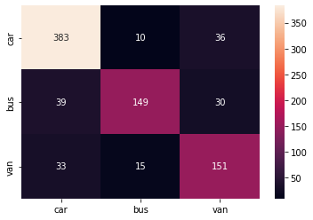

```python
evaluate_model_perf('SVC Base Model with PCA', yscale, y_pca_pred)
```

```python
display_model_matrix()
```

```
--------------------------------------------------------------------------------
Model Performance Comparision Matrix
--------------------------------------------------------------------------------
                        Model   Accuracy  Precision     Recall   F1 Score
0  SVC Base Model without PCA  98.108747  97.677305  98.096762  97.878631
1     SVC Base Model with PCA  80.732861  79.797754  77.835137  78.422715
--------------------------------------------------------------------------------
```

**Observation:**

We can see that the accuracy score of Train Data has reduced with PCA by about 18%. Overall reduction in all performance parameters.

## **4. Performance Improvement**

**A. Train another SVM on the components out of PCA. Tune the parameters to improve performance.**

```python
from sklearn.model_selection import GridSearchCV

params = {  'kernel'      : ('rbf', 'poly', 'sigmoid'),
            'gamma'       : ('scale','auto'),
            'C'           : [0.1,0.2,0.3,0.4,0.5,0.6,0.7,0.8,0.9,1],
            'class_weight': (None, 'balanced')
        }

# Use GridSearch to find best model
svm_pca_tuned = SVC()
clf = GridSearchCV(svm_pca_tuned, params, scoring='accuracy')
clf.fit(pca_5_df, yscale)
```

```
GridSearchCV(estimator=SVC(),
             param_grid={'C': [0.1, 0.2, 0.3, 0.4, 0.5, 0.6, 0.7, 0.8, 0.9, 1],
                         'class_weight': (None, 'balanced'),
                         'gamma': ('scale', 'auto'),
                         'kernel': ('rbf', 'poly', 'sigmoid')},
             scoring='accuracy')
```

**B. Share best Parameters observed from above step.**

```python
print('Best Parameters: ', clf.best_params_)
print('\nBest Estimators: ', clf.best_estimator_)
```

```
Best Parameters:  {'C': 1, 'class_weight': None, 'gamma': 'auto', 'kernel': 'rbf'}

Best Estimators:  SVC(C=1, gamma='auto')
```

```python
svm_pca_tuned = clf.best_estimator_
svm_pca_tuned.fit(pca_5_df, yscale)
y_pca_pred_best = svm_pca_tuned.predict(pca_5_df)
```

**C. Print Classification metrics for train data of above model and share relative improvement in performance in all the models along with insights.**

```
----------------------------------------
Classification report:
              precision    recall  f1-score   support

         bus       0.87      0.80      0.83       218
         car       0.89      0.92      0.91       429
         van       0.81      0.83      0.82       199

    accuracy                           0.87       846
   macro avg       0.86      0.85      0.85       846
weighted avg       0.87      0.87      0.87       846

----------------------------------------

Accuracy Score:	0.87

Precision:	0.86

Recall:		0.85

F1 Score:	0.85
----------------------------------------
Confusion Matrix:
[[174  30  14]
 [ 10 395  24]
 [ 15  18 166]]
----------------------------------------
```

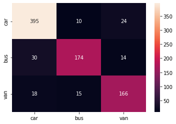

```python
evaluate_model_perf('SVC using PCA with Grid Search', yscale, y_pca_pred_best)
```

```python
display_model_matrix()
```

```
--------------------------------------------------------------------------------
Model Performance Comparision Matrix
--------------------------------------------------------------------------------
                            Model   Accuracy  Precision     Recall   F1 Score
0      SVC Base Model without PCA  98.108747  97.677305  98.096762  97.878631
2  SVC using PCA with Grid Search  86.879433  85.991507  85.102730  85.477234
1         SVC Base Model with PCA  80.732861  79.797754  77.835137  78.422715
--------------------------------------------------------------------------------
```

**Train SVC MODEL without PCA using GRID SEARCH**

```
Best Parameters:  {'C': 1, 'class_weight': None, 'gamma': 'scale', 'kernel': 'rbf'}

Best Estimators:  SVC(C=1)
----------------------------------------
Classification report:
              precision    recall  f1-score   support

         bus       0.99      0.98      0.98       218
         car       0.99      0.98      0.99       429
         van       0.95      0.98      0.97       199

    accuracy                           0.98       846
   macro avg       0.98      0.98      0.98       846
weighted avg       0.98      0.98      0.98       846

----------------------------------------

Accuracy Score:	0.98

Precision:	0.98

Recall:		0.98

F1 Score:	0.98
----------------------------------------
Confusion Matrix:
[[214   0   4]
 [  2 421   6]
 [  1   3 195]]
----------------------------------------
```

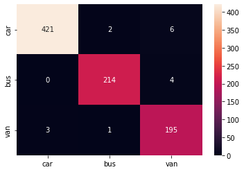

```python
# Use GridSearch to find best model
svm = SVC()
clf_tuned = GridSearchCV(svm, params, scoring='accuracy')
clf_tuned.fit(Xscale, yscale)
print('Best Parameters: ', clf_tuned.best_params_)
print('\nBest Estimators: ', clf_tuned.best_estimator_)
svm_tuned = clf_tuned.best_estimator_
svm_tuned.fit(Xscale, yscale)
y_pred_tuned = svm_tuned.predict(Xscale)
evaluate_model_perf('SVC Base Model with Grid Search', yscale, y_pred_tuned)
```

```python
display_model_matrix()
```

```
--------------------------------------------------------------------------------
Model Performance Comparision Matrix
--------------------------------------------------------------------------------
                             Model   Accuracy  Precision     Recall   F1 Score
0       SVC Base Model without PCA  98.108747  97.677305  98.096762  97.878631
3  SVC Base Model with Grid Search  98.108747  97.677305  98.096762  97.878631
2   SVC using PCA with Grid Search  86.879433  85.991507  85.102730  85.477234
1          SVC Base Model with PCA  80.732861  79.797754  77.835137  78.422715
--------------------------------------------------------------------------------
```

**Observation:**

- SVC Base Model performace is same with/without Grid Search. Base Model is already giving best performance with 98% accuracy. It has high accuracy, precision, recall, f1-score and very low misclassifications.
- Using PCA on Base SVC model reduced the performance by about 18%. A lot of misclassification can be seen.
- When we use the hyperparameters suggested by Grid Search with PCA, SVC model accuracy increased by 6%.

## **5. Data Understanding & Cleaning:**

**A. Explain pre-requisite/assumptions of PCA**

**Pre-requisites of using PCA**

Principal Component Analysis has only a few requirements that must be met in order to obtain meaningful results. The basic properties that the data set should have are:

- The correlation between the features should be linear.
- The data set should be free of outliers, i.e. individual data points that deviate strongly from the mass.
- If possible, the variables should be continuous.
- The result of the PCA becomes better, the larger the sample is.
- Data needs to be standardized before implementing PCA else it becomes difficult to identify optimal principal components.

**Assumptions of PCA**

- PCA assumes a correlation between features. ...
- PCA is sensitive to the scale of the features. ...
- PCA is not robust against outliers. ...
- PCA assumes a linear relationship between features. ...
- Technical implementations often assume no missing values.
- Independent variables are numeric in nature.

**B. Explain advantages and limitations of PCA.**

**Advantages**

- PCA is a widely used technique for decreasing the dimensions of a feature set.
- PCA can be used as a data reduction technique as it allows us to find the most important variables that are needed to describe a dataset.
- PCA can also be used to reduce the dimensionality of the data space in order to get insight on the inner structure of the data. This is helpful when dealing with large datasets.
- Principal components are independent of each other, so removes correlated features.
- PCA improves the performance of the ML algorithm as it eliminates correlated variables that don't contribute in any decision making.
- PCA helps in overcoming data overfitting issues by decreasing the number of features.
- PCA results in high variance and thus improves visualization.
- Reduction of noise since the maximum variation basis is chosen and so the small variations in the background are ignored automatically.

**Limitations**

- PCA effectiveness depends upon the scales of the attributes. If attributes have different scales, PCA will pick variable with highest variance rather than picking up attributes based on correlation
- Changing scales of the variables can change the PCA
- Interpreting PCA can become challenging due to presence of discrete data
- Presence of skew in data with long thick tail can impact the effectiveness of the PCA
- PCA assumes linear relationship between attributes. It is ineffective when relationships are non linear
- PCA can also lead to low model performance after applying it if the original dataset has a weak correlation or no correlation. The variables need to be related to one other to apply PCA perfectly.
- It is not suitable for small data sets
- It does not find the important factors but selects them based on the values. So, it is difficult to find the important factors.
- It does not have a strong mathematical structure behind it.
- It cannot find any non-linear relationships.